# RI analysis of irCLIPv2 and Re-CLIP dataset from EGF timecourse for HNRNPC and UPF1

Luca Ducoli

# 1. Characterization of RI events

```r
library(tidyverse)
library(Repitools)
library(AnnotationHub)
library(AnnotationDbi)
library(ggplot2)
library(plyranges)
library(GenomicRanges)
library(gintools)
library(rtracklayer)
library(EnrichedHeatmap)
library(circlize)
library(caTools)
library(cliProfiler)
library(paletteer)
library(gridExtra)
library(NbClust)
library(RColorBrewer)
library(ChIPpeakAnno)
library(data.table)
library(BRGenomics)
library(DESeq2)
library(ggpmisc)
library(eulerr)
library(memes)
library(BSgenome.Hsapiens.UCSC.hg38)
library(universalmotif)
library(SLIMFinderR)
library(ggraph)
library(ggrepel)
library(ggpubr)
```

## Density heatmap of distribution of RI transcripts

Given all the line of evidence that pinpoint to RI transcripts as the most interesting category, we decided to focus on this class for downstream analysis. First we checked where the RT stops are distributed across UTRs, exonic, and intronic regions.

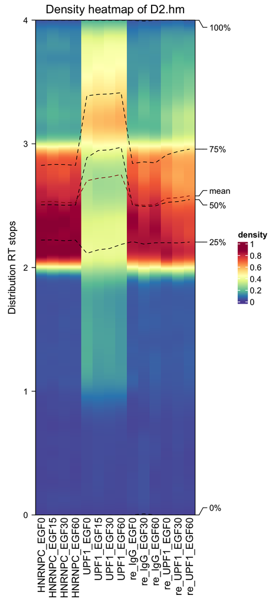

```r
#Density heatmap
df <- readRDS("~/Documents/Postdoc/PD_Projects/3_irCLIP-RNP/Seq/4_EGF_tc/4_Visualization/1_Distribution/RI_profile.rds")

df$Position[df$location == "exon"] <- df$Position[df$location == "exon"] + 1
df$Position[df$location == "intron"] <- df$Position[df$location == "intron"] + 2
df$Position[df$location == "UTR3"] <- df$Position[df$location == "UTR3"] + 3

length <- max(c(length(df$Position[df$rbp == "HNRNPC" & df$group == "EGF0"]), length(df$Position[df$rbp == "HNRNPC" & df$group == "EGF15"]),
                length(df$Position[df$rbp == "HNRNPC" & df$group == "EGF30"]), length(df$Position[df$rbp == "HNRNPC" & df$group == "EGF60"]),
              length(df$Position[df$rbp == "UPF1" & df$group == "EGF0"]), length(df$Position[df$rbp == "UPF1" & df$group == "EGF15"]),
                length(df$Position[df$rbp == "UPF1" & df$group == "EGF30"]), length(df$Position[df$rbp == "UPF1" & df$group == "EGF60"]),
              length(df$Position[df$rbp == "re-IgG" & df$group == "EGF0"]), length(df$Position[df$rbp == "re-IgG" & df$group == "EGF30"]),
              length(df$Position[df$rbp == "re-IgG" & df$group == "EGF60"]),
              length(df$Position[df$rbp == "re-UPF1" & df$group == "EGF0"]), length(df$Position[df$rbp == "re-UPF1" & df$group == "EGF30"]),
              length(df$Position[df$rbp == "re-UPF1" & df$group == "EGF60"])
              ))


D2.hm <- data.frame(HNRNPC_EGF0 = c(df$Position[df$rbp == "HNRNPC" & df$group == "EGF0"],rep(NA, length - length(df$Position[df$rbp == "HNRNPC" & df$group == "EGF0"]))),
                    HNRNPC_EGF15 = c(df$Position[df$rbp == "HNRNPC" & df$group == "EGF15"],rep(NA, length - length(df$Position[df$rbp == "HNRNPC" & df$group == "EGF15"]))),
                    HNRNPC_EGF30 = c(df$Position[df$rbp == "HNRNPC" & df$group == "EGF30"],rep(NA, length - length(df$Position[df$rbp == "HNRNPC" & df$group == "EGF30"]))),
                    HNRNPC_EGF60 = c(df$Position[df$rbp == "HNRNPC" & df$group == "EGF60"],rep(NA, length - length(df$Position[df$rbp == "HNRNPC" & df$group == "EGF60"]))),
                    UPF1_EGF0 = c(df$Position[df$rbp == "UPF1" & df$group == "EGF0"],rep(NA, length - length(df$Position[df$rbp == "UPF1" & df$group == "EGF0"]))),
                    UPF1_EGF15 = c(df$Position[df$rbp == "UPF1" & df$group == "EGF15"],rep(NA, length - length(df$Position[df$rbp == "UPF1" & df$group == "EGF15"]))),
                    UPF1_EGF30 = c(df$Position[df$rbp == "UPF1" & df$group == "EGF30"],rep(NA, length - length(df$Position[df$rbp == "UPF1" & df$group == "EGF30"]))),
                    UPF1_EGF60 = c(df$Position[df$rbp == "UPF1" & df$group == "EGF60"],rep(NA, length - length(df$Position[df$rbp == "UPF1" & df$group == "EGF60"]))),
                    re_IgG_EGF0 = c(df$Position[df$rbp == "re_IgG" & df$group == "EGF0"],rep(NA, length - length(df$Position[df$rbp == "re_IgG" & df$group == "EGF0"]))),
                    re_IgG_EGF30 = c(df$Position[df$rbp == "re_IgG" & df$group == "EGF30"],rep(NA, length - length(df$Position[df$rbp == "re_IgG" & df$group == "EGF30"]))),
                    re_IgG_EGF60 = c(df$Position[df$rbp == "re_IgG" & df$group == "EGF60"],rep(NA, length - length(df$Position[df$rbp == "re_IgG" & df$group == "EGF60"]))),
                    re_UPF1_EGF0 = c(df$Position[df$rbp == "re_UPF1" & df$group == "EGF0"],rep(NA, length - length(df$Position[df$rbp == "re_UPF1" & df$group == "EGF0"]))),
                    re_UPF1_EGF30 = c(df$Position[df$rbp == "re_UPF1" & df$group == "EGF30"],rep(NA, length - length(df$Position[df$rbp == "re_UPF1" & df$group == "EGF30"]))),
                    re_UPF1_EGF60 = c(df$Position[df$rbp == "re_UPF1" & df$group == "EGF60"],rep(NA, length - length(df$Position[df$rbp == "re_UPF1" & df$group == "EGF60"]))))

ComplexHeatmap::densityHeatmap(D2.hm, col = rev(brewer.pal(30, "Spectral")) , cluster_columns = FALSE, ylim = c(0,4), show_quantiles = TRUE, ylab = "Distribution RT stops")
```

```r
# Save the plot as pdf
pdf("~/Documents/Postdoc/PD_Projects/3_irCLIP-RNP/Seq/4_EGF_tc/4_Visualization/1_Distribution/Distribution_density_HNRNPC_UPF1_allregions.pdf", height = 10, width = 4.5)
ComplexHeatmap::densityHeatmap(D2.hm, col = rev(brewer.pal(30, "Spectral")),  cluster_columns = FALSE, ylim = c(0,4), show_quantiles = TRUE, ylab = "Density of RT stops location across RI transcripts")
dev.off()
```

## 3’UTR magnification

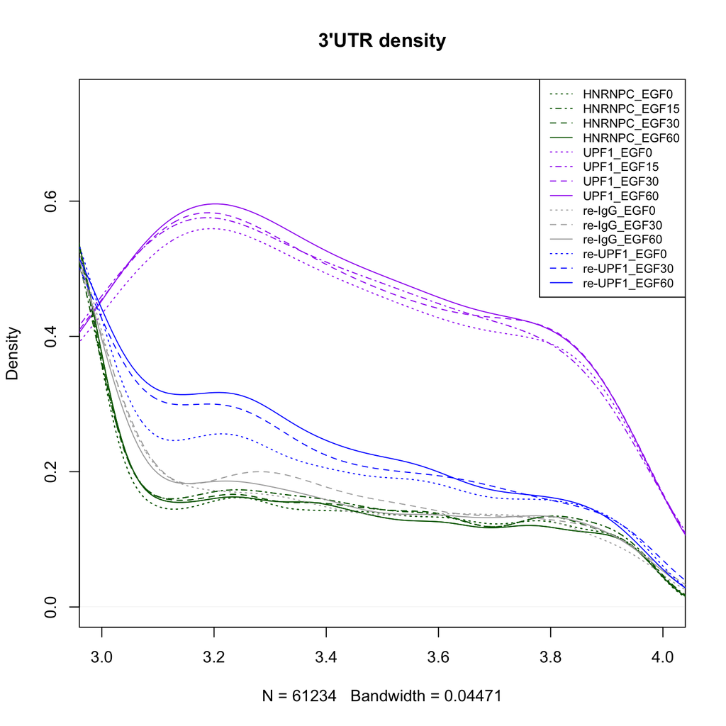

```r
#3'UTR only
plot(density(df$Position[df$rbp == "HNRNPC" & df$group == "EGF0"]), xlim = c(3, 4), ylim = c(0, 0.75), col="darkgreen", main="3'UTR density", lty=3)
lines(density(df$Position[df$rbp == "HNRNPC" & df$group == "EGF15"]), col="darkgreen", lty=4)
lines(density(df$Position[df$rbp == "HNRNPC" & df$group == "EGF30"]), col="darkgreen", lty=2)
lines(density(df$Position[df$rbp == "HNRNPC" & df$group == "EGF60"]), col="darkgreen", lty=1)
lines(density(df$Position[df$rbp == "UPF1" & df$group == "EGF0"]), col="purple", lty=3)
lines(density(df$Position[df$rbp == "UPF1" & df$group == "EGF15"]), col="purple", lty=4)
lines(density(df$Position[df$rbp == "UPF1" & df$group == "EGF30"]), col="purple", lty=2)
lines(density(df$Position[df$rbp == "UPF1" & df$group == "EGF60"]), col="purple", lty=1)
lines(density(df$Position[df$rbp == "HNRNPC" & df$group == "EGF0"]), col="darkgreen", lty=3)
lines(density(df$Position[df$rbp == "HNRNPC" & df$group == "EGF15"]), col="darkgreen", lty=4)
lines(density(df$Position[df$rbp == "HNRNPC" & df$group == "EGF30"]), col="darkgreen", lty=2)
lines(density(df$Position[df$rbp == "HNRNPC" & df$group == "EGF60"]), col="darkgreen", lty=1)
lines(density(df$Position[df$rbp == "re_IgG" & df$group == "EGF0"]), col="darkgrey", lty=3)
lines(density(df$Position[df$rbp == "re_IgG" & df$group == "EGF30"]), col="darkgrey", lty=2)
lines(density(df$Position[df$rbp == "re_IgG" & df$group == "EGF60"]), col="darkgrey", lty=1)
lines(density(df$Position[df$rbp == "re_UPF1" & df$group == "EGF0"]), col="blue", lty=3)
lines(density(df$Position[df$rbp == "re_UPF1" & df$group == "EGF30"]), col="blue", lty=2)
lines(density(df$Position[df$rbp == "re_UPF1" & df$group == "EGF60"]), col="blue", lty=1)
legend(x = "topright", lty = c(3,4,2,1,3,4,2,1,3,2,1,3,2,1), text.font = 1, cex = 0.75,
       col= c(rep("darkgreen", 4), rep("purple", 4), rep("darkgrey", 3),  rep("blue", 3)),text.col = "black",
       legend=c("HNRNPC_EGF0", "HNRNPC_EGF15", "HNRNPC_EGF30", "HNRNPC_EGF60",
                "UPF1_EGF0", "UPF1_EGF15", "UPF1_EGF30", "UPF1_EGF60",
                "re-IgG_EGF0", "re-IgG_EGF30", "re-IgG_EGF60",
                "re-UPF1_EGF0", "re-UPF1_EGF30", "re-UPF1_EGF60"))
```

```r
# Save the plot as pdf
pdf("~/Documents/Postdoc/PD_Projects/3_irCLIP-RNP/Seq/4_EGF_tc/4_Visualization/1_Distribution/Distribution_density_3UTR_HNRNPC_UPF1_allregions.pdf", height = 7.5, width = 7.5)
plot(density(df$Position[df$rbp == "HNRNPC" & df$group == "EGF0"]), xlim = c(3, 4), ylim = c(0, 0.75), col="darkgreen", main="3'UTR density", lty=3)
lines(density(df$Position[df$rbp == "HNRNPC" & df$group == "EGF15"]), col="darkgreen", lty=4)
lines(density(df$Position[df$rbp == "HNRNPC" & df$group == "EGF30"]), col="darkgreen", lty=2)
lines(density(df$Position[df$rbp == "HNRNPC" & df$group == "EGF60"]), col="darkgreen", lty=1)
lines(density(df$Position[df$rbp == "UPF1" & df$group == "EGF0"]), col="purple", lty=3)
lines(density(df$Position[df$rbp == "UPF1" & df$group == "EGF15"]), col="purple", lty=4)
lines(density(df$Position[df$rbp == "UPF1" & df$group == "EGF30"]), col="purple", lty=2)
lines(density(df$Position[df$rbp == "UPF1" & df$group == "EGF60"]), col="purple", lty=1)
lines(density(df$Position[df$rbp == "HNRNPC" & df$group == "EGF0"]), col="darkgreen", lty=3)
lines(density(df$Position[df$rbp == "HNRNPC" & df$group == "EGF15"]), col="darkgreen", lty=4)
lines(density(df$Position[df$rbp == "HNRNPC" & df$group == "EGF30"]), col="darkgreen", lty=2)
lines(density(df$Position[df$rbp == "HNRNPC" & df$group == "EGF60"]), col="darkgreen", lty=1)
lines(density(df$Position[df$rbp == "re_IgG" & df$group == "EGF0"]), col="darkgrey", lty=3)
lines(density(df$Position[df$rbp == "re_IgG" & df$group == "EGF30"]), col="darkgrey", lty=2)
lines(density(df$Position[df$rbp == "re_IgG" & df$group == "EGF60"]), col="darkgrey", lty=1)
lines(density(df$Position[df$rbp == "re_UPF1" & df$group == "EGF0"]), col="blue", lty=3)
lines(density(df$Position[df$rbp == "re_UPF1" & df$group == "EGF30"]), col="blue", lty=2)
lines(density(df$Position[df$rbp == "re_UPF1" & df$group == "EGF60"]), col="blue", lty=1)
legend(x = "topright", lty = c(3,4,2,1,3,4,2,1,3,2,1,3,2,1), text.font = 1, cex = 0.75,
       col= c(rep("darkgreen", 4), rep("purple", 4), rep("darkgrey", 3),  rep("blue", 3)),text.col = "black",
       legend=c("HNRNPC_EGF0", "HNRNPC_EGF15", "HNRNPC_EGF30", "HNRNPC_EGF60",
                "UPF1_EGF0", "UPF1_EGF15", "UPF1_EGF30", "UPF1_EGF60",
                "re-IgG_EGF0", "re-IgG_EGF30", "re-IgG_EGF60",
                "re-UPF1_EGF0", "re-UPF1_EGF30", "re-UPF1_EGF60"))
dev.off()
```

```r
#Test irCLIP
ks.test.reclip <- data.frame(reUPF160vsreIgG0 = ks.test(df$Position[df$Position > 3 & df$rbp == "re_IgG" & df$group == "EGF0"], df$Position[df$Position > 3 & df$rbp == "re_UPF1" & df$group == "EGF60"])$p.value, reUPF160vsreIgG30 = ks.test(df$Position[df$Position > 3 & df$rbp == "re_IgG" & df$group == "EGF30"], df$Position[df$Position > 3 & df$rbp == "re_UPF1" & df$group == "EGF60"])$p.value , reUPF160vsreIgG60 = ks.test(df$Position[df$Position > 3 & df$rbp == "re_IgG" & df$group == "EGF60"], df$Position[df$Position > 3 & df$rbp == "re_UPF1" & df$group == "EGF60"])$p.value,
                            reUPF160vsreHNRNPC0 = ks.test(df$Position[df$Position > 3 & df$rbp == "HNRNPC" & df$group == "EGF0"], df$Position[df$Position > 3 & df$rbp == "re_UPF1" & df$group == "EGF60"])$p.value, reUPF160vsreHNRNPC15 = ks.test(df$Position[df$Position > 3 & df$rbp == "HNRNPC" & df$group == "EGF15"], df$Position[df$Position > 3 & df$rbp == "re_UPF1" & df$group == "EGF60"])$p.value, reUPF160vsreHNRNPC30 = ks.test(df$Position[df$Position > 3 & df$rbp == "HNRNPC" & df$group == "EGF30"], df$Position[df$Position > 3 & df$rbp == "re_UPF1" & df$group == "EGF60"])$p.value , reUPF160vsreHNRNPC60 = ks.test(df$Position[df$Position > 3 & df$rbp == "HNRNPC" & df$group == "EGF60"], df$Position[df$Position > 3 & df$rbp == "re_UPF1" & df$group == "EGF60"])$p.value,
                      reUPF160vsreUPF10 = ks.test(df$Position[df$Position > 3 & df$rbp == "re_UPF1" & df$group == "EGF0"], df$Position[df$Position > 3 & df$rbp == "re_UPF1" & df$group == "EGF60"])$p.value, reUPF160vsreUPF130 = ks.test(df$Position[df$Position > 3 & df$rbp == "re_UPF1" & df$group == "EGF30"], df$Position[df$Position > 3 & df$rbp == "re_UPF1" & df$group == "EGF60"])$p.value
)

ks.test.reclip
```

| reUPF160vsreIgG0 | reUPF160vsreIgG30 | reUPF160vsreIgG60 | reUPF160vsreHNRNPC0 | reUPF160vsreHNRNPC15 | reUPF160vsreHNRNPC30 | reUPF160vsreHNRNPC60 | reUPF160vsreUPF10 | reUPF160vsreUPF130 |
| --- | --- | --- | --- | --- | --- | --- | --- | --- |
| 3.339214e-05 | 0.0005054441 | 3.202764e-06 | 0 | 1.187939e-14 | 0 | 7.620571e-13 | 3.607423e-05 | 0.09059375 |

# 3. Analysis of differentially bound regions across EGF stimulation in RI transcripts

Since previous results point to the 3’UTR as the region where the HNRNPC-UPF1 co-binding is happening, we decided to analyze the total signal across these regions during EGF stimulation. We selected 3’UTRs of RI transcripts having maximal Zscore(log2FC) > 0 against time point 0. We termed these regions: EGF-responsive 3’UTRs of RI transcripts.

```r
#Get transcript names from rMATs output
gtf <- rtracklayer::import('~/Documents/Postdoc/PD_Projects/3_irCLIP-RNP/MS/siRNA_EGF_SG/2_EGF/8_DTE_analysis/0_UPF1_HNRNPC/1_DTE/Genome/gencode.v39.annotation.gtf')
gtf_df=as.data.frame(gtf)

#Get AS_events
AS_event <- read.delim("~/Documents/Postdoc/PD_Projects/3_irCLIP-RNP/Seq/4_EGF_tc/4_Visualization/1_Distribution/PC_AS_events.txt", header = TRUE)
AS_event <- AS_event %>% mutate("gene_id" = sapply(strsplit(AS_event$region, "_"), function(x) x[1]),
                                "gene_name"= sapply(strsplit(AS_event$region, "_"), function(x) x[2]),
                                "chr"= sapply(strsplit(AS_event$region, "_"), function(x) x[3]),
                                "strand"= sapply(strsplit(AS_event$region, "_"), function(x) x[4]),
                                "start" = sapply(strsplit(AS_event$region, "_"), function(x) x[5]),
                                "end"= sapply(strsplit(AS_event$region, "_"), function(x) x[6])) %>% dplyr::select(c(region,chr,start,end, strand, gene_id, gene_name, AS))

AS_event <- subset(AS_event, AS == "RI")

AS_event_tx <- merge(AS_event %>% dplyr::select(region,gene_id,AS), gtf_df[gtf_df$type == "transcript",], by = "gene_id") %>% dplyr::select(c(seqnames,start,end,transcript_id, strand, gene_id, gene_name, AS))

AS_event_bed <- AS_event %>% dplyr::select(chr, start, end, strand, region, gene_id, AS)
AS_event_tx_bed <- AS_event_tx %>% dplyr::select(seqnames, start, end, strand, transcript_id, gene_id)

#bedtools to get regions inside transcripts
AS_event_tx2 <- bedtoolsr::bt.intersect(AS_event_bed, AS_event_tx_bed, loj = TRUE)
AS_event_tx2 <- unique(AS_event_tx2)

colnames(AS_event_tx2) <- c("AS_chr", "AS_start", "AS_end", "AS_strand", "AS_region", "AS_geneID", "AS_event", "TX_chr", "TX_start", "TX_end", "TX_strand", "TX_id", "TX_geneID")
AS_event_tx2 <- AS_event_tx2 %>% mutate(geneIDmatch = case_when(AS_geneID != TX_geneID  ~ "0",AS_geneID == TX_geneID ~ "1"))
AS_event_tx2 <- subset(AS_event_tx2, geneIDmatch > 0)

#Load annotation
txdb <- loadDb("~/Documents/Postdoc/PD_Projects/3_irCLIP-RNP/MS/siRNA_EGF_SG/2_EGF/8_DTE_analysis/0_UPF1_HNRNPC/1_DTE/Genome/gencode.v39.annotation.sqlite")
k <- keys(txdb, keytype = "TXNAME")
tx2gene <- AnnotationDbi::select(txdb, k, "GENEID", "TXNAME")
k <- keys(txdb, keytype = "EXONNAME")
ex2gene <- AnnotationDbi::select(txdb, k, "GENEID", "EXONNAME")

#3utr
utr3 <- unlist(threeUTRsByTranscript(txdb, use.names=TRUE))
utr3$TXNAME <- names(utr3)
names(utr3) <- NULL
u3 <- annoGR2DF(utr3)
u3 <- merge(u3, tx2gene, by = "TXNAME")
u3 <- u3 %>% dplyr::rename(TX_id = TXNAME)

u3_AS_event <- merge(AS_event_tx2, u3, by = "TX_id")

#Granges function
granges_AS <- function(AS_type, start, end){
  AS <- AS_event
  AS <- data.frame("region" = AS$region,
                       "gene_id" = sapply(strsplit(AS$region, "_"), function(x) x[1]),
                       "gene_name"= sapply(strsplit(AS$region, "_"), function(x) x[2]),
                       "chr"= sapply(strsplit(AS$region, "_"), function(x) x[3]),
                        "start" = sapply(strsplit(AS$region, "_"), function(x) x[start]),
                       "end"= sapply(strsplit(AS$region, "_"), function(x) x[end]),
                       "strand" = sapply(strsplit(AS$region, "_"), function(x) x[4]),
                       "AS" = AS$AS )

  AS_u3.gr <- makeGRangesFromDataFrame(u3_AS_event[u3_AS_event$AS_event == AS_type, ], keep.extra.columns = TRUE)
  mcols(AS_u3.gr) <- mcols(AS_u3.gr)[6]
  AS_u3.gr <- unique_granges(AS_u3.gr)
  colnames(mcols(AS_u3.gr))[colnames(mcols(AS_u3.gr)) == "AS_region"] <- "region"
  AS_u3.gr$AS_event <- AS_type
  return(AS_u3.gr)
}

#Prepare granges
AS_utr3reg.gr <- granges_AS("RI", 7, 10)
saveRDS(AS_utr3reg.gr, "~/Documents/Postdoc/PD_Projects/3_irCLIP-RNP/Seq/4_EGF_tc/4_Visualization/2_Heatmap/UTR3_event_granges.rds")
AS_utr3reg.gr$AS_region <- AS_utr3reg.gr$region
AS_utr3reg.gr$region <- sapply(strsplit(AS_utr3reg.gr$region, "_"), function(x) x[2])
AS_utr3reg.gr <- split(AS_utr3reg.gr, AS_utr3reg.gr$region)

for (i in 1:length(names(AS_utr3reg.gr))) {
  AS_utr3reg.gr[[i]] <- reduceWithMcols(AS_utr3reg.gr[[i]])
}

AS_utr3reg.gr <- unlist(AS_utr3reg.gr)
AS_utr3reg.gr$region <- sapply(AS_utr3reg.gr$region, function(x) {paste(unique(unlist(strsplit(x, split = "|", fixed = TRUE))), collapse = "|")})
AS_utr3reg.gr$AS_event <- sapply(AS_utr3reg.gr$AS_event, function(x) {paste(unique(unlist(strsplit(x, split = "|", fixed = TRUE))), collapse = "|")})
AS_utr3reg.gr$AS_region <- sapply(AS_utr3reg.gr$AS_region, function(x) {paste(unique(unlist(strsplit(x, split = "|", fixed = TRUE))), collapse = "|")})
names(AS_utr3reg.gr) <- NULL
AS_utr3reg.gr$ID <- paste(AS_utr3reg.gr$region,"UTR",1:length(AS_utr3reg.gr$region), sep = "_")

#Coverage function
coverage_matrix <- function(gr, rbp, cond){
gr.p <- subset(gr, strand == "+")
gr.p$width_region <- end(gr.p) - start(gr.p)
gr.m <- subset(gr, strand == "-")
gr.m$width_region <- end(gr.m) - start(gr.m)

#Load bigwigfile
dir <- "~/Documents/Postdoc/PD_Projects/3_irCLIP-RNP/Seq/4_EGF_tc/2_Bigwig/"
bw.EGF0.r1.p <- import.bw(paste(dir, rbp, "_A431_EGF0", cond,"R1.p.bw", sep = ""))
bw.EGF0.r1.m <- import.bw(paste(dir, rbp, "_A431_EGF0", cond,"R1.m.bw", sep = ""))
bw.EGF0.r2.p <- import.bw(paste(dir, rbp, "_A431_EGF0", cond,"R2.p.bw", sep = ""))
bw.EGF0.r2.m <- import.bw(paste(dir, rbp, "_A431_EGF0", cond,"R2.m.bw", sep = ""))

bw.EGF15.r1.p <- import.bw(paste(dir, rbp, "_A431_EGF15", cond,"R1.p.bw", sep = ""))
bw.EGF15.r1.m <- import.bw(paste(dir, rbp, "_A431_EGF15", cond,"R1.m.bw", sep = ""))
bw.EGF15.r2.p <- import.bw(paste(dir, rbp, "_A431_EGF15", cond,"R2.p.bw", sep = ""))
bw.EGF15.r2.m <- import.bw(paste(dir, rbp, "_A431_EGF15", cond,"R2.m.bw", sep = ""))

bw.EGF30.r1.p <- import.bw(paste(dir, rbp, "_A431_EGF30", cond,"R1.p.bw", sep = ""))
bw.EGF30.r1.m <- import.bw(paste(dir, rbp, "_A431_EGF30", cond,"R1.m.bw", sep = ""))
bw.EGF30.r2.p <- import.bw(paste(dir, rbp, "_A431_EGF30", cond,"R2.p.bw", sep = ""))
bw.EGF30.r2.m <- import.bw(paste(dir, rbp, "_A431_EGF30", cond,"R2.m.bw", sep = ""))

bw.EGF60.r1.p <- import.bw(paste(dir, rbp, "_A431_EGF60", cond,"R1.p.bw", sep = ""))
bw.EGF60.r1.m <- import.bw(paste(dir, rbp, "_A431_EGF60", cond,"R1.m.bw", sep = ""))
bw.EGF60.r2.p <- import.bw(paste(dir, rbp, "_A431_EGF60", cond,"R2.p.bw", sep = ""))
bw.EGF60.r2.m <- import.bw(paste(dir, rbp, "_A431_EGF60", cond,"R2.m.bw", sep = ""))

#Create profile matrices
gr.p$EGF0_1 <- getCountsByRegions(bw.EGF0.r1.p, gr.p)
gr.p$EGF0_2 <- getCountsByRegions(bw.EGF0.r2.p, gr.p)
gr.p$EGF15_1 <- getCountsByRegions(bw.EGF15.r1.p, gr.p)
gr.p$EGF15_2 <- getCountsByRegions(bw.EGF15.r2.p, gr.p)
gr.p$EGF30_1 <- getCountsByRegions(bw.EGF30.r1.p, gr.p)
gr.p$EGF30_2 <- getCountsByRegions(bw.EGF30.r2.p, gr.p)
gr.p$EGF60_1 <- getCountsByRegions(bw.EGF60.r1.p, gr.p)
gr.p$EGF60_2 <- getCountsByRegions(bw.EGF60.r2.p, gr.p)

gr.m$EGF0_1 <- getCountsByRegions(bw.EGF0.r1.m, gr.m)
gr.m$EGF0_2 <- getCountsByRegions(bw.EGF0.r2.m, gr.m)
gr.m$EGF15_1 <- getCountsByRegions(bw.EGF15.r1.m, gr.m)
gr.m$EGF15_2 <- getCountsByRegions(bw.EGF15.r2.m, gr.m)
gr.m$EGF30_1 <- getCountsByRegions(bw.EGF30.r1.m, gr.m)
gr.m$EGF30_2 <- getCountsByRegions(bw.EGF30.r2.m, gr.m)
gr.m$EGF60_1 <- getCountsByRegions(bw.EGF60.r1.m, gr.m)
gr.m$EGF60_2 <- getCountsByRegions(bw.EGF60.r2.m, gr.m)

#Merge replicates
gr <- bind_ranges(gr.p, gr.m)

all <- as.data.frame(mcols(gr))
colnames(all)[grep("EGF", colnames(all))] <- paste(rbp, colnames(all)[grep("EGF", colnames(all))], sep = "_")
df

return(all)
}

coverage_matrix_KD <- function(gr, rbp, cond){
gr.p <- subset(gr, strand == "+")
gr.p$width_region <- end(gr.p) - start(gr.p)
gr.m <- subset(gr, strand == "-")
gr.m$width_region <- end(gr.m) - start(gr.m)

#Load bigwigfile
dir <- "~/Documents/Postdoc/PD_Projects/3_irCLIP-RNP/Seq/5_Knockdown/2_Bigwig/"
bw.EGF0Ctrl.r1.p <- import.bw(paste(dir, rbp, "_CTRi_EGF0_R1.p.bw", sep = ""))
bw.EGF0Ctrl.r1.m <- import.bw(paste(dir, rbp, "_CTRi_EGF0_R1.m.bw", sep = ""))
bw.EGF0Ctrl.r2.p <- import.bw(paste(dir, rbp, "_CTRi_EGF0_R2.p.bw", sep = ""))
bw.EGF0Ctrl.r2.m <- import.bw(paste(dir, rbp, "_CTRi_EGF0_R2.m.bw", sep = ""))

bw.EGF0KD.r1.p <- import.bw(paste(dir, rbp, cond, "EGF0_R1.p.bw", sep = ""))
bw.EGF0KD.r1.m <- import.bw(paste(dir, rbp, cond, "EGF0_R1.m.bw", sep = ""))
bw.EGF0KD.r2.p <- import.bw(paste(dir, rbp, cond, "EGF0_R2.p.bw", sep = ""))
bw.EGF0KD.r2.m <- import.bw(paste(dir, rbp, cond, "EGF0_R2.m.bw", sep = ""))

bw.EGF60Ctrl.r1.p <- import.bw(paste(dir, rbp, "_CTRi_EGF60_R1.p.bw", sep = ""))
bw.EGF60Ctrl.r1.m <- import.bw(paste(dir, rbp, "_CTRi_EGF60_R1.m.bw", sep = ""))
bw.EGF60Ctrl.r2.p <- import.bw(paste(dir, rbp, "_CTRi_EGF60_R2.p.bw", sep = ""))
bw.EGF60Ctrl.r2.m <- import.bw(paste(dir, rbp, "_CTRi_EGF60_R2.m.bw", sep = ""))

bw.EGF60KD.r1.p <- import.bw(paste(dir, rbp, cond, "EGF60_R1.p.bw", sep = ""))
bw.EGF60KD.r1.m <- import.bw(paste(dir, rbp, cond, "EGF60_R1.m.bw", sep = ""))
bw.EGF60KD.r2.p <- import.bw(paste(dir, rbp, cond, "EGF60_R2.p.bw", sep = ""))
bw.EGF60KD.r2.m <- import.bw(paste(dir, rbp, cond, "EGF60_R2.m.bw", sep = ""))

#Create profile matrices
gr.p$EGF0Ctrl_1 <- getCountsByRegions(bw.EGF0Ctrl.r1.p, gr.p)
gr.p$EGF0Ctrl_2 <- getCountsByRegions(bw.EGF0Ctrl.r2.p, gr.p)
gr.p$EGF0KD_1 <- getCountsByRegions(bw.EGF0KD.r1.p, gr.p)
gr.p$EGF0KD_2 <- getCountsByRegions(bw.EGF0KD.r2.p, gr.p)
gr.p$EGF60Ctrl_1 <- getCountsByRegions(bw.EGF60Ctrl.r1.p, gr.p)
gr.p$EGF60Ctrl_2 <- getCountsByRegions(bw.EGF60Ctrl.r2.p, gr.p)
gr.p$EGF60KD_1 <- getCountsByRegions(bw.EGF60KD.r1.p, gr.p)
gr.p$EGF60KD_2 <- getCountsByRegions(bw.EGF60KD.r2.p, gr.p)

gr.m$EGF0Ctrl_1 <- getCountsByRegions(bw.EGF0Ctrl.r1.m, gr.m)
gr.m$EGF0Ctrl_2 <- getCountsByRegions(bw.EGF0Ctrl.r2.m, gr.m)
gr.m$EGF0KD_1 <- getCountsByRegions(bw.EGF0KD.r1.m, gr.m)
gr.m$EGF0KD_2 <- getCountsByRegions(bw.EGF0KD.r2.m, gr.m)
gr.m$EGF60Ctrl_1 <- getCountsByRegions(bw.EGF60Ctrl.r1.m, gr.m)
gr.m$EGF60Ctrl_2 <- getCountsByRegions(bw.EGF60Ctrl.r2.m, gr.m)
gr.m$EGF60KD_1 <- getCountsByRegions(bw.EGF60KD.r1.m, gr.m)
gr.m$EGF60KD_2 <- getCountsByRegions(bw.EGF60KD.r2.m, gr.m)

#Merge replicates
gr <- bind_ranges(gr.p, gr.m)

all <- as.data.frame(mcols(gr))
colnames(all)[grep("EGF", colnames(all))] <- paste(rbp, colnames(all)[grep("EGF", colnames(all))], sep = "_")
df

return(all)
}

#Timecourse total signal
HNRNPC_3utr <- coverage_matrix(AS_utr3reg.gr, "HNRNPC", "_")
UPF1_3utr <- coverage_matrix(AS_utr3reg.gr, "UPF1", "_HMW_")

#KD total signal
kdHNRNPC_3utr <- coverage_matrix_KD(AS_utr3reg.gr, "HNRNPC", "_UPF1i_")
kdUPF1_3utr <- coverage_matrix_KD(AS_utr3reg.gr, "UPF1", "_hnCi_")

#Save coverage matrix
write.table(HNRNPC_3utr, file = "~/Documents/Postdoc/PD_Projects/3_irCLIP-RNP/Seq/4_EGF_tc/4_Visualization/2_Heatmap/HNRNPC_UTR3_total_signal.txt", row.names = F, quote = F, sep = "\t")
write.table(UPF1_3utr, file = "~/Documents/Postdoc/PD_Projects/3_irCLIP-RNP/Seq/4_EGF_tc/4_Visualization/2_Heatmap/UPF1_UTR3_total_signal.txt", row.names = F, quote = F, sep = "\t")

write.table(kdHNRNPC_3utr, file = "~/Documents/Postdoc/PD_Projects/3_irCLIP-RNP/Seq/4_EGF_tc/4_Visualization/2_Heatmap/kdHNRNPC_UTR3_total_signal.txt", row.names = F, quote = F, sep = "\t")
write.table(kdUPF1_3utr, file = "~/Documents/Postdoc/PD_Projects/3_irCLIP-RNP/Seq/4_EGF_tc/4_Visualization/2_Heatmap/kdUPF1_UTR3_total_signal.txt", row.names = F, quote = F, sep = "\t")
```

## Scatterplot of HNRNPC and UPF1 total signal at 3’UTR of RI transcripts during EGF stimulation.

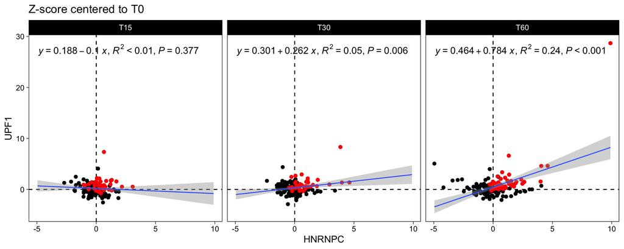

```r
#Prepare data for DESeq analysis
HNRNPC_reg <- HNRNPC_3utr
UPF1_reg <- UPF1_3utr

#Timecourse
HNRNPC_design <- data.frame(label = colnames(HNRNPC_reg)[grep("EGF", colnames(HNRNPC_reg))], condition = rep(c("T0", "T15", "T30", "T60"), each = 2), replicate = rep(c("1", "2"), 4))
HNRNPC_reg_mat <- as.matrix(HNRNPC_reg[,grep("EGF", colnames(HNRNPC_reg))])
rownames(HNRNPC_reg_mat) <- HNRNPC_reg$ID

UPF1_design <- data.frame(label = colnames(UPF1_reg)[grep("EGF", colnames(UPF1_reg))], condition = rep(c("T0", "T15", "T30", "T60"), each = 2), replicate = rep(c("1", "2"), 4))
UPF1_reg_mat <- as.matrix(UPF1_reg[,grep("EGF", colnames(UPF1_reg))])
rownames(UPF1_reg_mat) <- UPF1_reg$ID

#KD
kdHNRNPC_reg <- kdHNRNPC_3utr
kdUPF1_reg <- kdUPF1_3utr

kdHNRNPC_design <- data.frame(label = colnames(kdHNRNPC_reg)[grep("EGF", colnames(kdHNRNPC_reg))], time = rep(c("T0", "T60"), each = 4), replicate = rep(c("1", "2"), 4),
                              condition = rep(c("Ctrl", "KD", "Ctrl", "KD"), each = 2))
kdHNRNPC_reg_mat <- as.matrix(kdHNRNPC_reg[,grep("EGF", colnames(kdHNRNPC_reg))])
rownames(kdHNRNPC_reg_mat) <- kdHNRNPC_reg$ID

kdUPF1_design <- data.frame(label = colnames(kdUPF1_reg)[grep("EGF", colnames(kdUPF1_reg))], time = rep(c("T0", "T60"), each = 4), replicate = rep(c("1", "2"), 4),
                              condition = rep(c("Ctrl", "KD", "Ctrl", "KD"), each = 2))
kdUPF1_reg_mat <- as.matrix(kdUPF1_reg[,grep("EGF", colnames(kdUPF1_reg))])
rownames(kdUPF1_reg_mat) <- kdUPF1_reg$ID

#Zscore estimation using DESeq2
deseq_total_rt <- function(data, design, rbp){
  dds <- DESeqDataSetFromMatrix(data, design, ~ condition)
  keep <- rowSums(counts(dds)) >= 10
  dds <- dds[keep,]
  dds <- estimateSizeFactors(dds)
  normalized_counts <- counts(dds, normalized=TRUE)
  dds <- DESeq(dds)
  res <- results(dds)
  dds_logFC <- coef(dds, SE = F)
  dds_SE <- coef(dds, SE = T)
  dds_cent <- coef(dds, SE = F)/coef(dds, SE = T)
  dds_cent <- dds_cent[,c(2:4)]
  colnames(dds_cent) <- c(paste(rep(paste(rbp, "EGF",sep = "_"), 3), c("15", "30", "60"), sep = "_"))
  return(list(table = dds_cent, res = res, norm_counts = normalized_counts, dds = dds))
}

kdHNRNPC_design$condition2 <- paste(kdHNRNPC_design$time, kdHNRNPC_design$condition, sep = "_")
kdUPF1_design$condition2 <- paste(kdUPF1_design$time, kdUPF1_design$condition, sep = "_")

deseq_total_rt_kd <- function(data, design, rbp, TP){
  dds <- DESeqDataSetFromMatrix(data, design, ~ condition)
  keep <- rowSums(counts(dds)) >= 10
  dds <- dds[keep,]
  dds <- estimateSizeFactors(dds)
  dds <- dds[,dds$time == TP]
  normalized_counts <- counts(dds, normalized=TRUE)
  dds <- DESeq(dds)
  res <- results(dds)
  dds_logFC <- coef(dds, SE = F)
  dds_SE <- coef(dds, SE = T)
  dds_cent <- coef(dds, SE = F)/coef(dds, SE = T)
  colnames(dds_cent)[2] <- paste(rbp, TP, "CtrlvsKD", sep = "_")
  return(list(table = dds_cent, res = res, norm_counts = normalized_counts, dds = dds, dds_SE = dds_SE))
}

HNRNPC_cent <- deseq_total_rt(HNRNPC_reg_mat, HNRNPC_design, "HNRNPC")
UPF1_cent <- deseq_total_rt(UPF1_reg_mat, UPF1_design, "UPF1")
kdHNRNPC_cent <- deseq_total_rt_kd(kdHNRNPC_reg_mat, kdHNRNPC_design, "HNRNPC", "T0")
kdUPF1_cent <- deseq_total_rt_kd(kdUPF1_reg_mat, kdUPF1_design, "UPF1", "T0")
kdHNRNPC_cent2 <- deseq_total_rt_kd(kdHNRNPC_reg_mat, kdHNRNPC_design, "HNRNPC", "T60")
kdUPF1_cent2 <- deseq_total_rt_kd(kdUPF1_reg_mat, kdUPF1_design, "UPF1", "T60")

merge.all <- function(x, ..., by = "row.names") {
  L <- list(...)
  for (i in seq_along(L)) {
    x <- merge(x, L[[i]], by = by)
    rownames(x) <- x$Row.names
    x$Row.names <- NULL
  }
  return(x)
}

all <- merge.all(HNRNPC_cent$table,UPF1_cent$table, kdHNRNPC_cent$table, kdUPF1_cent$table, kdHNRNPC_cent2$table, kdUPF1_cent2$table)

all$HNRNPC_max_lfc <- pmax(all$HNRNPC_EGF_15,all$HNRNPC_EGF_30, all$HNRNPC_EGF_60)
all$HNRNPC_min_lfc <- pmin(all$HNRNPC_EGF_15,all$HNRNPC_EGF_30, all$HNRNPC_EGF_60)
all$HNRNPC_max_lfc_all <- ifelse(abs(all$HNRNPC_max_lfc) > abs(all$HNRNPC_min_lfc),  all$HNRNPC_max_lfc, all$HNRNPC_min_lfc)

all$UPF1_max_lfc <- pmax(all$UPF1_EGF_15,all$UPF1_EGF_30, all$UPF1_EGF_60)
all$UPF1_min_lfc <- pmin(all$UPF1_EGF_15,all$UPF1_EGF_30, all$UPF1_EGF_60)
all$UPF1_max_lfc_all <- ifelse(abs(all$UPF1_max_lfc) > abs(all$UPF1_min_lfc),  all$UPF1_max_lfc, all$UPF1_min_lfc)

#Scatterplot
merge1 <- reshape2::melt(all %>% dplyr::select(HNRNPC_EGF_15:HNRNPC_EGF_60), value.name = "HNRNPC")
merge1$ID <- rep(rownames(all), length(levels(factor(merge1$variable))))
merge2 <- reshape2::melt(all %>% dplyr::select(UPF1_EGF_15:UPF1_EGF_60), value.name = "UPF1")
merge2$ID <- rep(rownames(all), length(levels(factor(merge2$variable))))
merge_melt <- cbind(merge1[,c(1,2)],merge2[,c(2,3)])
merge_melt$TP <- rep(c("T15", "T30", "T60") , each = dim(all)[1])

ggplot3 <- ggplot(data=merge_melt, aes(x=HNRNPC, y=UPF1)) +
  geom_hline(yintercept=0, linetype="dashed", color = "black") +
  geom_vline(xintercept=0, linetype="dashed", color = "black") +
  geom_point() +
  geom_point(data = subset(merge_melt, ID %in% rownames(all)[(all$HNRNPC_max_lfc_all > 0 & all$UPF1_max_lfc_all > 0)]), color = "red" ) +
  geom_smooth(method='lm', formula= y~x, size=0.5, fullrange=TRUE) +
  stat_poly_eq(formula = y ~ x,
               aes(label = paste(..eq.label.., ..rr.label.., ..p.value.label.., sep = "*`,`~")),
               parse = TRUE,
               label.x.npc = "left",
               vstep = 0.05)+
  theme_linedraw() + theme(panel.grid.major = element_blank(), legend.position = "bottom",
        panel.grid.minor = element_blank(),
        panel.background = element_blank(),
        axis.line = element_blank()) + ggtitle("Z-score centered to T0") + facet_wrap(~TP, nrow = 1)

ggplot3
```

```r
#Save the plot as pdf
pdf("~/Documents/Postdoc/PD_Projects/3_irCLIP-RNP/Seq/4_EGF_tc/4_Visualization/2_Heatmap/Zscore_corr.pdf", height = 4, width = 10)
ggplot3
dev.off()
```

# 4. Integration with differential expression and stability results

At this point, we integrated the differential expression and stability results with the genes of EGF-responsive RI 3’UTRs to identify which regions are co-bound and co-regulated (co-BR) by HNRNPC and UPF1.

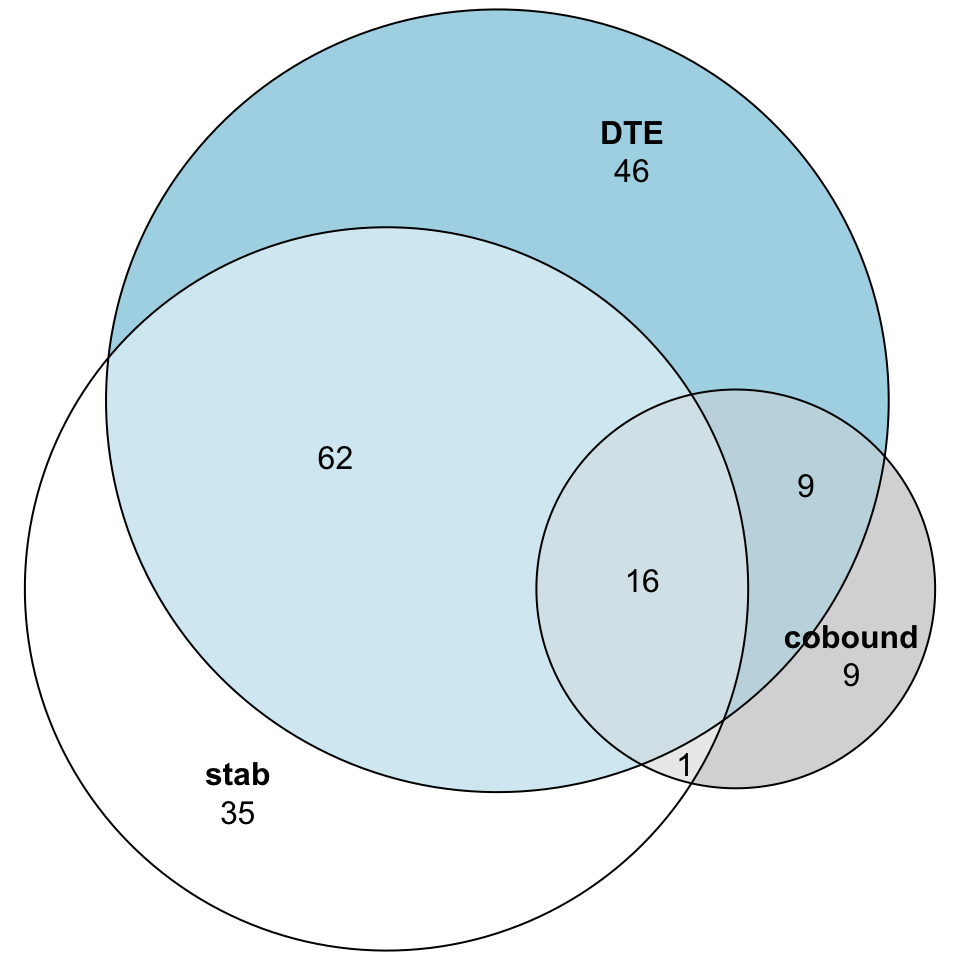

```r
#Subset results
all <- subset(all, HNRNPC_max_lfc_all > 0 & UPF1_max_lfc_all > 0)

AS_utr3reg.gr.sub <- AS_utr3reg.gr[AS_utr3reg.gr$ID %in% HNRNPC_reg$ID[HNRNPC_reg$ID %in% rownames(all)]]
cobound <- as.data.frame(mcols(AS_utr3reg.gr.sub))

#Overlap between cobound and stability and DE genes
tx2gene <- read.delim("~/Documents/Postdoc/PD_Projects/3_irCLIP-RNP/MS/siRNA_EGF_SG/2_EGF/4_mRNA_stability_assay/4_DTE_timecourse/Analysis/1_DTE/Annotation_transcripts_genes.txt", header = TRUE)

#DTE results
DTE <- read.delim("~/Documents/Postdoc/PD_Projects/3_irCLIP-RNP/MS/siRNA_EGF_SG/2_EGF/8_DTE_analysis/0_UPF1_HNRNPC/1_DTE/AS_HNRNPC_UPF1_logFC_high_sign.txt", header = TRUE)
colnames(DTE)[6] <- "GENEID"
DTE <- merge(DTE, tx2gene, by = "GENEID", all.x = TRUE)
DTE <- subset(DTE,  AS_event == "RI")

#Stability results
stab <- read.delim("~/Documents/Postdoc/PD_Projects/3_irCLIP-RNP/MS/siRNA_EGF_SG/2_EGF/4_mRNA_stability_assay/4_DTE_timecourse/Analysis/1_DTE/Limma_sign_transcript_upset.txt", header = TRUE)
colnames(stab)[1] <- "TXNAME"
stab <- merge(stab, tx2gene, by = "TXNAME", all.x = TRUE)
stab <- subset(stab,  AS_event == "RI")

lt.tsk = list(stab = unique(stab$SYMBOL),
              cobound = unique(cobound$region),
              DTE = unique(DTE$SYMBOL)
)

fromList <- function (input) {
  elements <- unique(unlist(input))
  data <- unlist(lapply(input, function(x) {
    x <- as.vector(match(elements, x))
  }))
  data[is.na(data)] <- as.integer(0)
  data[data != 0] <- as.integer(1)
  data <- data.frame(matrix(data, ncol = length(input), byrow = F))
  data <- data[which(rowSums(data) != 0), ]
  names(data) <- names(input)
  # ... Except now it conserves your original value names!
  row.names(data) <- elements
  return(data)
}

# Binary table with colnames:
sign.proteins2 <- fromList(lt.tsk)
sign.proteins2$funct <- paste(sign.proteins2$stab, sign.proteins2$cobound, sign.proteins2$DTE, sep = "_")

plot(euler(lt.tsk), quantities = TRUE)
```

```r
cobound.funct <- cobound[cobound$region %in% rownames(sign.proteins2)[sign.proteins2$funct %in% c("0_1_1", "1_1_0", "1_1_1")],]

cobound_exp <- as.data.frame(cobound.funct %>% separate_rows(AS_region, sep = "\\|"))
rMATs.tr <- read.delim("~/Documents/Postdoc/PD_Projects/3_irCLIP-RNP/MS/siRNA_EGF_SG/2_EGF/8_DTE_analysis/0_UPF1_HNRNPC/1_DTE/AS_HNRNPC_UPF1_transcripts.txt", header = TRUE)
rMATs.tr <- subset(rMATs.tr,  AS_event == "RI")

cobound_exp <- merge(cobound_exp, rMATs.tr %>% dplyr::select(AS_region, TX_id, TX_geneID), by = "AS_region")
cobound_exp$stab <- ifelse(cobound_exp$TX_id %in% stab$TXNAME, 1, 0)
cobound_exp$DTE <- ifelse(cobound_exp$TX_id %in% DTE$TX_id, 1, 0)

cobound_funct2 <- unique(cobound_exp %>% dplyr::select(AS_region, region, ID, stab, DTE))

cobound_funct2 <- as.data.frame(cobound_funct2 %>% group_by(ID) %>% dplyr::summarise(stab = sum(stab, na.rm = TRUE), DTE = sum(DTE, na.rm = TRUE)))
cobound_funct2$stab <- ifelse(cobound_funct2$stab > 0, 1, 0)
cobound_funct2$DTE <- ifelse(cobound_funct2$DTE > 0, 1, 0)

AS_utr3reg.gr.sub <- AS_utr3reg.gr[AS_utr3reg.gr$ID %in% cobound.funct$ID]
write.table(as.data.frame(mcols(AS_utr3reg.gr.sub)), file = "~/Documents/Postdoc/PD_Projects/3_irCLIP-RNP/Seq/4_EGF_tc/4_Visualization/2_Heatmap/HNRNPC_UPF1_cobound_genes.txt", quote = F, row.names = F, sep = "\t")
```

```r
#Save the plot as pdf
pdf("~/Documents/Postdoc/PD_Projects/3_irCLIP-RNP/Seq/4_EGF_tc/4_Visualization/2_Heatmap/Overlap_DTE_stab_cobound.pdf", height = 5, width = 5)
plot(euler(lt.tsk), quantities = TRUE)
dev.off()
```

## Heatmap of co-bound and co-regulated 3’UTR of RI transcripts in irCLIPv2 datasets

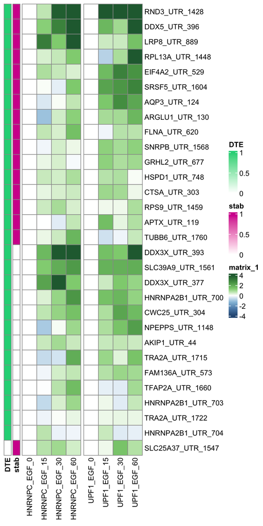

```r
#Heatmap timecourse table
hm_table <- all %>% dplyr::select(HNRNPC_EGF_15:UPF1_EGF_60)
hm_table <- hm_table[rownames(hm_table) %in% cobound.funct$ID,]

hm_table2 <- cbind(hm_table, HNRNPC_EGF_0 = rep(0, dim(hm_table)[1]), UPF1_EGF_0 = rep(0, dim(hm_table)[1]))
hm_table2 <- hm_table2 %>% dplyr::select(HNRNPC_EGF_0, HNRNPC_EGF_15, HNRNPC_EGF_30, HNRNPC_EGF_60,
                                         UPF1_EGF_0, UPF1_EGF_15, UPF1_EGF_30, UPF1_EGF_60)
hm_table2 <- as.matrix(hm_table2)

my.breaks <- c(seq(-4, 4, by=0.01))
my.colors <- rev(c(paletteer_c("ggthemes::Green-Blue-White Diverging", length(my.breaks))))

annotation_row <- cobound_funct2
rownames(annotation_row) <- annotation_row$ID
annotation_row$ID <- NULL
annotation_row <- annotation_row[match(rownames(hm_table2), rownames(annotation_row)), ]
annotation_row$row_sums <- rowSums(hm_table2)
annotation_row <- annotation_row %>% dplyr::arrange(-row_sums) %>% dplyr::arrange(-stab) %>% dplyr::arrange(-DTE)
hm_table2 <- hm_table2[match(rownames(annotation_row), rownames(hm_table2)), ]

ph <- pheatmap(hm_table2, scale = "none", annotation_row = annotation_row[,-3], show_rownames = T, cluster_rows = FALSE, clustering_distance_rows = "correlation", cluster_cols = FALSE, clustering_method = "ward.D2",
         gaps_col = c(4,8), color = my.colors, breaks = my.breaks, display_numbers = FALSE)#, cutree_rows = 4)
ph
```

```r
#Save the plot as pdf
pdf("~/Documents/Postdoc/PD_Projects/3_irCLIP-RNP/Seq/4_EGF_tc/4_Visualization/2_Heatmap/Zscore_heatmap.pdf", height = 10, width = 5)
ph
dev.off()
```

## Scatterplot of co-bound and co-regulated 3’UTR of RI transcripts in irCLIPv2 knockdown datasets

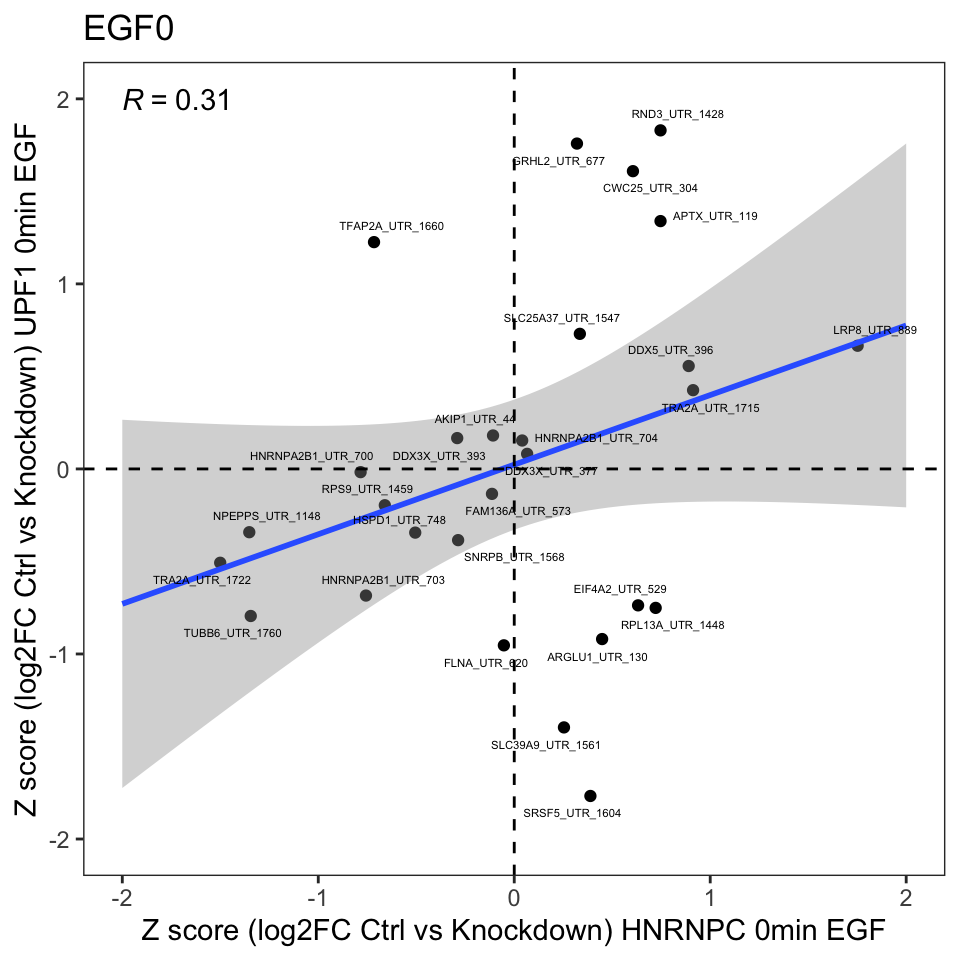

```r
library(MASS)
#Heatmap knockdown
df <- all %>% dplyr::select(HNRNPC_T0_CtrlvsKD, HNRNPC_T60_CtrlvsKD, UPF1_T0_CtrlvsKD, UPF1_T60_CtrlvsKD)
df <- df[rownames(df) %in% cobound.funct$ID,]

plot_0min <- ggplot(df, aes(x=HNRNPC_T0_CtrlvsKD, y=UPF1_T0_CtrlvsKD) ) +
  geom_point() +
  geom_smooth(method = "lm", se = T, fullrange=TRUE) +
  geom_text_repel(aes(label = rownames(df)), size = 1.5) +
  theme_bw()+ geom_hline(yintercept = 0, linetype="dashed") + geom_vline(xintercept = 0, linetype="dashed") +
  theme(panel.grid=element_blank(), legend.position="none")+  ylab("Z score (log2FC Ctrl vs Knockdown) UPF1 0min EGF") + xlab("Z score (log2FC Ctrl vs Knockdown) HNRNPC 0min EGF") +
  ylim(-2,2) +
  xlim(-2,2) +
  ggtitle("EGF0") + stat_cor(aes(label = ..r.label..), label.y = 2)


plot_60min <- ggplot(df, aes(x=HNRNPC_T60_CtrlvsKD, y=UPF1_T60_CtrlvsKD) ) +
  geom_point() +
  geom_smooth(method = "lm", se = T, fullrange=TRUE) +
  geom_text_repel(aes(label = rownames(df)), size = 1.5) +
  theme_bw()+ geom_hline(yintercept = 0, linetype="dashed") + geom_vline(xintercept = 0, linetype="dashed") +
  theme(panel.grid=element_blank(), legend.position="none")+  ylab("Z score (log2FC Ctrl vs Knockdown) UPF1 60min EGF") + xlab("Z score (log2FC Ctrl vs Knockdown) HNRNPC 60min EGF") +
  ylim(-2,2) +
  xlim(-2,2) +
  ggtitle("EGF60") + stat_cor(aes(label = ..r.label..), label.y = 2)

plot_0min
```

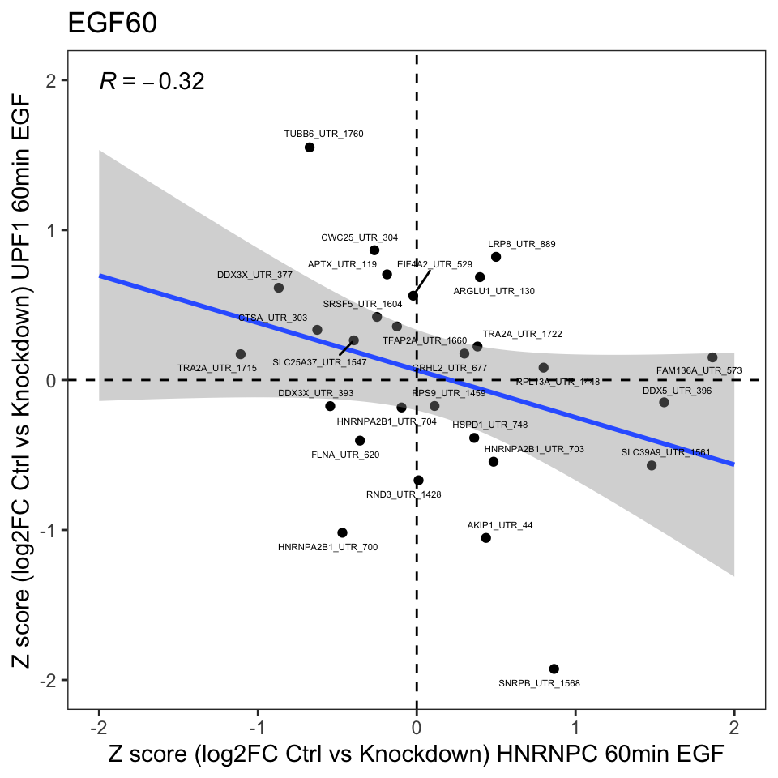

```r
plot_60min
```

```r
#Save the plot as pdf
pdf("~/Documents/Postdoc/PD_Projects/3_irCLIP-RNP/Seq/4_EGF_tc/4_Visualization/2_Heatmap/Zscore_scatterplot_corr_KD.pdf", height = 5, width = 5)
plot_0min
plot_60min
dev.off()
```

# 5. De-novo motif analysis using STREME

We have performed de-novo motif analysis of EGF-responsive co-BR 3’UTRs of RI transcipts.

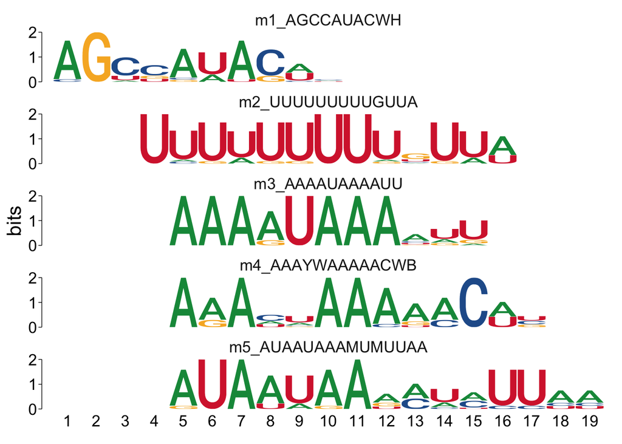

```r
#Subset for re-CLIP
AS_utr3reg.gr.sub <- AS_utr3reg.gr.sub[AS_utr3reg.gr.sub$ID %in% cobound.funct$ID,]

#Get sequence
gr.seq <- AS_utr3reg.gr.sub %>% get_sequence(BSgenome.Hsapiens.UCSC.hg38)

streme <- runStreme(gr.seq, control = "shuffle", alph = "rna", minw = 10, maxw=15, align = "center")
streme %>%
  to_list() %>%
  view_motifs(tryRC = FALSE)
```

```r
#Save the plot as pdf
pdf("~/Documents/Postdoc/PD_Projects/3_irCLIP-RNP/Seq/4_EGF_tc/4_Visualization/2_Heatmap/Motif_enrichment.pdf", height = 5, width = 5)
streme %>%
  to_list() %>%
  view_motifs(tryRC = FALSE)
dev.off()
```

# 5. Analysis of co-BR regions in Re-CLIP dataset

## Profile plot of EGF-responsive co-BR 3’UTRs of RI transcripts.

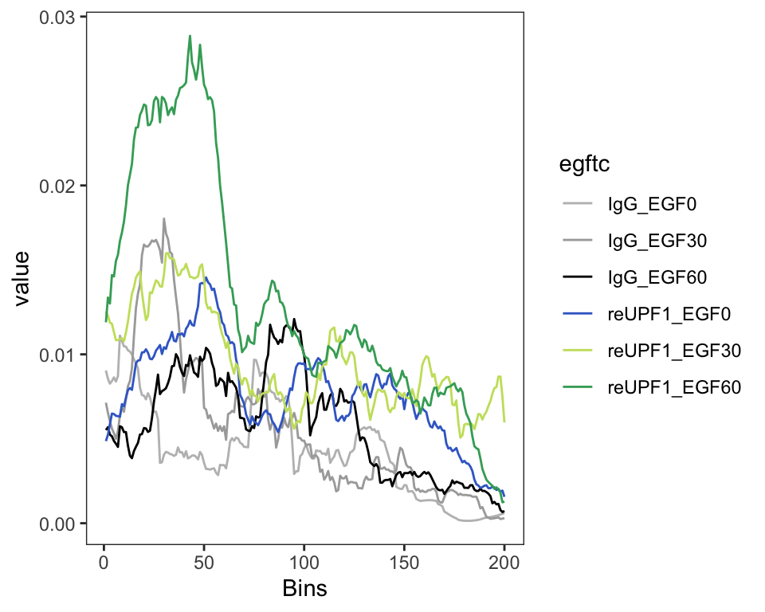

```r
#Coverage function
coverage_matrix_rclip <- function(gr, rbp, cond){
  gr.p <- subset(gr, strand == "+")
  gr.p$width_region <- end(gr.p) - start(gr.p)
  gr.m <- subset(gr, strand == "-")
  gr.m$width_region <- end(gr.m) - start(gr.m)

  #Load bigwigfile
  dir <- "~/Documents/Postdoc/PD_Projects/3_irCLIP-RNP/Seq/6_reclip-EGF_tcupf1/3_Bigwig_sum/"
  bw.EGF0.r1.p <- import.bw(paste(dir, rbp, "_A431_hnC_EGF0", cond,"R1.p.scaleddewseq.bw", sep = ""))
  bw.EGF0.r1.m <- import.bw(paste(dir, rbp, "_A431_hnC_EGF0", cond,"R1.m.scaleddewseq.bw", sep = ""))
  bw.EGF0.r2.p <- import.bw(paste(dir, rbp, "_A431_hnC_EGF0", cond,"R2.p.scaleddewseq.bw", sep = ""))
  bw.EGF0.r2.m <- import.bw(paste(dir, rbp, "_A431_hnC_EGF0", cond,"R2.m.scaleddewseq.bw", sep = ""))

  bw.EGF30.r1.p <- import.bw(paste(dir, rbp, "_A431_hnC_EGF30", cond,"R1.p.scaleddewseq.bw", sep = ""))
  bw.EGF30.r1.m <- import.bw(paste(dir, rbp, "_A431_hnC_EGF30", cond,"R1.m.scaleddewseq.bw", sep = ""))
  bw.EGF30.r2.p <- import.bw(paste(dir, rbp, "_A431_hnC_EGF30", cond,"R2.p.scaleddewseq.bw", sep = ""))
  bw.EGF30.r2.m <- import.bw(paste(dir, rbp, "_A431_hnC_EGF30", cond,"R2.m.scaleddewseq.bw", sep = ""))

  bw.EGF60.r1.p <- import.bw(paste(dir, rbp, "_A431_hnC_EGF60", cond,"R1.p.scaleddewseq.bw", sep = ""))
  bw.EGF60.r1.m <- import.bw(paste(dir, rbp, "_A431_hnC_EGF60", cond,"R1.m.scaleddewseq.bw", sep = ""))
  bw.EGF60.r2.p <- import.bw(paste(dir, rbp, "_A431_hnC_EGF60", cond,"R2.p.scaleddewseq.bw", sep = ""))
  bw.EGF60.r2.m <- import.bw(paste(dir, rbp, "_A431_hnC_EGF60", cond,"R2.m.scaleddewseq.bw", sep = ""))

  #Create profile matrices#
  EGF0.mat1.p = normalizeToMatrix(bw.EGF0.r1.p, gr.p, value_column = "score", mean_mode = "w0", extend = 0, k = 200, w = 20, background = 0, smooth = TRUE, target_ratio = 1, limit = NA)
  EGF0.mat1.m = normalizeToMatrix(bw.EGF0.r1.m, gr.m, value_column = "score", mean_mode = "w0", extend = 0, k = 200, w = 20, background = 0, smooth = FALSE, target_ratio = 1, limit = NA)
  EGF0.mat2.p = normalizeToMatrix(bw.EGF0.r2.p, gr.p, value_column = "score", mean_mode = "w0", extend = 0, k = 200, w = 20, background = 0, smooth = FALSE, target_ratio = 1, limit = NA)
  EGF0.mat2.m = normalizeToMatrix(bw.EGF0.r2.m, gr.m, value_column = "score", mean_mode = "w0", extend = 0, k = 200, w = 20, background = 0, smooth = FALSE, target_ratio = 1, limit = NA)

  EGF30.mat1.p = normalizeToMatrix(bw.EGF30.r1.p, gr.p, value_column = "score", mean_mode = "w0", extend = 0, k = 200, w = 20, background = 0, smooth = FALSE, target_ratio = 1, limit = NA)
  EGF30.mat1.m = normalizeToMatrix(bw.EGF30.r1.m, gr.m, value_column = "score", mean_mode = "w0", extend = 0, k = 200, w = 20, background = 0, smooth = FALSE, target_ratio = 1, limit = NA)
  EGF30.mat2.p = normalizeToMatrix(bw.EGF30.r2.p, gr.p, value_column = "score", mean_mode = "w0", extend = 0, k = 200, w = 20, background = 0, smooth = FALSE, target_ratio = 1, limit = NA)
  EGF30.mat2.m = normalizeToMatrix(bw.EGF30.r2.m, gr.m, value_column = "score", mean_mode = "w0", extend = 0, k = 200, w = 20, background = 0, smooth = FALSE, target_ratio = 1, limit = NA)

  EGF60.mat1.p = normalizeToMatrix(bw.EGF60.r1.p, gr.p, value_column = "score", mean_mode = "w0", extend = 0, k = 200, w = 20, background = 0, smooth = FALSE, target_ratio = 1, limit = NA)
  EGF60.mat1.m = normalizeToMatrix(bw.EGF60.r1.m, gr.m, value_column = "score", mean_mode = "w0", extend = 0, k = 200, w = 20, background = 0, smooth = FALSE, target_ratio = 1, limit = NA)
  EGF60.mat2.p = normalizeToMatrix(bw.EGF60.r2.p, gr.p, value_column = "score", mean_mode = "w0", extend = 0, k = 200, w = 20, background = 0, smooth = FALSE, target_ratio = 1, limit = NA)
  EGF60.mat2.m = normalizeToMatrix(bw.EGF60.r2.m, gr.m, value_column = "score", mean_mode = "w0", extend = 0, k = 200, w = 20, background = 0, smooth = FALSE, target_ratio = 1, limit = NA)

  #Merge replicates
  EGF0.mat_list.p = list(EGF0.mat1.p, EGF0.mat2.p)
  EGF0.mat.p = getSignalsFromList(EGF0.mat_list.p)
  rownames(EGF0.mat.p) <- gr.p$ID

  EGF30.mat_list.p = list(EGF30.mat1.p, EGF30.mat2.p)
  EGF30.mat.p = getSignalsFromList(EGF30.mat_list.p)
  rownames(EGF30.mat.p) <- gr.p$ID

  EGF60.mat_list.p = list(EGF60.mat1.p, EGF60.mat2.p)
  EGF60.mat.p = getSignalsFromList(EGF60.mat_list.p)
  rownames(EGF60.mat.p) <- gr.p$ID

  EGF0.mat_list.m = list(EGF0.mat1.m, EGF0.mat2.m)
  EGF0.mat.m = getSignalsFromList(EGF0.mat_list.m)
  rownames(EGF0.mat.m) <- gr.m$ID

  EGF30.mat_list.m = list(EGF30.mat1.m, EGF30.mat2.m)
  EGF30.mat.m = getSignalsFromList(EGF30.mat_list.m)
  rownames(EGF30.mat.m) <- gr.m$ID

  EGF60.mat_list.m = list(EGF60.mat1.m, EGF60.mat2.m)
  EGF60.mat.m = getSignalsFromList(EGF60.mat_list.m)
  rownames(EGF60.mat.m) <- gr.m$ID

  #Combine p and m
  EGF0.mat <- rbind(EGF0.mat.p, EGF0.mat.m)
  rownames(EGF0.mat) <- c(gr.p$ID, gr.m$ID)
  EGF30.mat <- rbind(EGF30.mat.p, EGF30.mat.m)
  rownames(EGF30.mat) <- c(gr.p$ID, gr.m$ID)
  EGF60.mat <- rbind(EGF60.mat.p, EGF60.mat.m)
  rownames(EGF60.mat) <- c(gr.p$ID, gr.m$ID)
  return(list(EGF0 = EGF0.mat, EGF30 = EGF30.mat, EGF60 = EGF60.mat))
}

IgG_mat <- coverage_matrix_rclip(AS_utr3reg.gr.sub, "IgG", "_")
UPF1_mat <- coverage_matrix_rclip(AS_utr3reg.gr.sub, "UPF1", "_HMW_")

profileplot  <-  function(x){
    S1.mat <- x$EGF0[]
    S2.mat <- x$EGF30[]
    S3.mat <- x$EGF60[]

    k = 20
    S1.mat2 = t(runmean(t(S1.mat), k))
    S2.mat2 = t(runmean(t(S2.mat), k))
    S3.mat2 = t(runmean(t(S3.mat), k))

    S1.gg <- data.frame("value" = colMeans(S1.mat2, na.rm=TRUE))
    S1.gg$type <- "EGF0"
    S1.gg$xlab <- c(1:dim(S1.mat2)[2])
    S2.gg <- data.frame("value" = colMeans(S2.mat2, na.rm=TRUE))
    S2.gg$type <- "EGF30"
    S2.gg$xlab <- c(1:dim(S2.mat2)[2])
    S3.gg <- data.frame("value" = colMeans(S3.mat2, na.rm=TRUE))
    S3.gg$type <- "EGF60"
    S3.gg$xlab <- c(1:dim(S3.mat2)[2])

    all <- rbind(S1.gg,S2.gg,S3.gg)
    all$type <- factor(all$type)
    all$type <- factor(all$type, levels = c("EGF60", "EGF30", "EGF0"))
    return(list(all = all, EGF0 = S1.mat2, EGF30 = S2.mat2, EGF60 = S3.mat2))
  }

IgG.plot <- profileplot(IgG_mat)
UPF1.plot <- profileplot(UPF1_mat)

IgG.plot$all$rbp <- "IgG"
UPF1.plot$all$rbp <- "reUPF1"

all_profile <- rbind(IgG.plot$all, UPF1.plot$all)
all_profile$egftc <- paste(all_profile$rbp, all_profile$type, sep = "_")

all.plot <- all_profile %>%
  ggplot( aes(x=xlab, y=value, group = egftc, color = egftc)) +
  geom_line() +
  # scale_linetype_manual(values = c("EGF60" = 1, "EGF30" = 4, "EGF0" = 2)) +
  scale_color_manual(values = c("IgG_EGF0" = "grey",  "IgG_EGF30" = "darkgrey", "IgG_EGF60" = "black",  "reUPF1_EGF60" = "#3fa966",  "reUPF1_EGF30" = "#c8e06a",  "reUPF1_EGF0"= "#3d6ccd"))+
  xlab("Bins") +
  theme_bw() +
  theme( panel.grid.major = element_blank(),
         panel.grid.minor = element_blank(),
         panel.background = element_blank(),
         axis.line = element_blank(),
         plot.title = element_text(hjust = 0.5)) #+
  #facet_wrap(vars(rbp), ncol = 1, nrow = 2)

all.plot
```

```r
#Save the plot as pdf
pdf("~/Documents/Postdoc/PD_Projects/3_irCLIP-RNP/Seq/4_EGF_tc/4_Visualization/2_Heatmap/Profileplot_reCLIP.pdf", height = 4, width = 5)
all.plot
dev.off()
```

## Enriched of EGF-responsive co-BR 3’UTRs of RI transcripts.

[figure not shown]

```r
#Prepare matrices for enriched heatmap
UPF1_mat$EGF60[] <- UPF1.plot$EGF60
UPF1_mat$EGF30[] <- UPF1.plot$EGF30
UPF1_mat$EGF0[] <- UPF1.plot$EGF0

IgG_mat$EGF60[] <- IgG.plot$EGF60
IgG_mat$EGF30[] <- IgG.plot$EGF30
IgG_mat$EGF0[] <- IgG.plot$EGF0

col_fun = colorRamp2(c(0, 0.05), c("white", "darkgreen"))

#Generate heatmap
EH <-  EnrichedHeatmap(UPF1_mat$EGF60, name = "UPF1_EGF60",  col = col_fun, top_annotation = NULL, use_raster=TRUE,  raster_quality = 10) +
  EnrichedHeatmap(UPF1_mat$EGF30, name = "UPF1_EGF30", col = col_fun, top_annotation = NULL,  use_raster=TRUE, raster_quality = 10) +
    EnrichedHeatmap(UPF1_mat$EGF0, name = "UPF1_EGF0", col = col_fun, top_annotation = NULL,  use_raster=TRUE, raster_quality = 10) +
  EnrichedHeatmap(IgG_mat$EGF0, name = "IgG_EGF0", col = col_fun, top_annotation = NULL,  use_raster=TRUE, raster_quality = 10) +
  EnrichedHeatmap(IgG_mat$EGF30, name = "IgG_EGF30", col = col_fun, top_annotation = NULL,  use_raster=TRUE, raster_quality = 10) +
  EnrichedHeatmap(IgG_mat$EGF60, name = "IgG_EGF60", col = col_fun, show_row_names = TRUE, use_raster=TRUE, top_annotation = NULL,  raster_quality = 10)

EH
```

```r
#Save the plot as pdf
pdf("~/Documents/Postdoc/PD_Projects/3_irCLIP-RNP/Seq/4_EGF_tc/4_Visualization/2_Heatmap/EnrichedHeatmap_reCLIP.pdf", height = 5, width = 10)
EH
dev.off()
```

All the visualizations were saved as pdf and modified in illustrator.